# Coronavirus stats

Brian Bowling

2020-04-01

I know there are a lot of visualizations dealing with the coronavirus, but sometimes I think they get so complex that they hide a few key points. So here’s my take on them using data from the European Centre for Disease Prevention and Control.

The obvious caveats are that the daily number of new Covid-19 cases and coronavirus-related deaths rely on the accurate testing of patients and the willingness of countries to share data with their own citizens and the rest of the world.

With that in mind, here’s what the data shows about daily new cases and new deaths reported in the United States and worldwide. Note that both are still ramping upward.

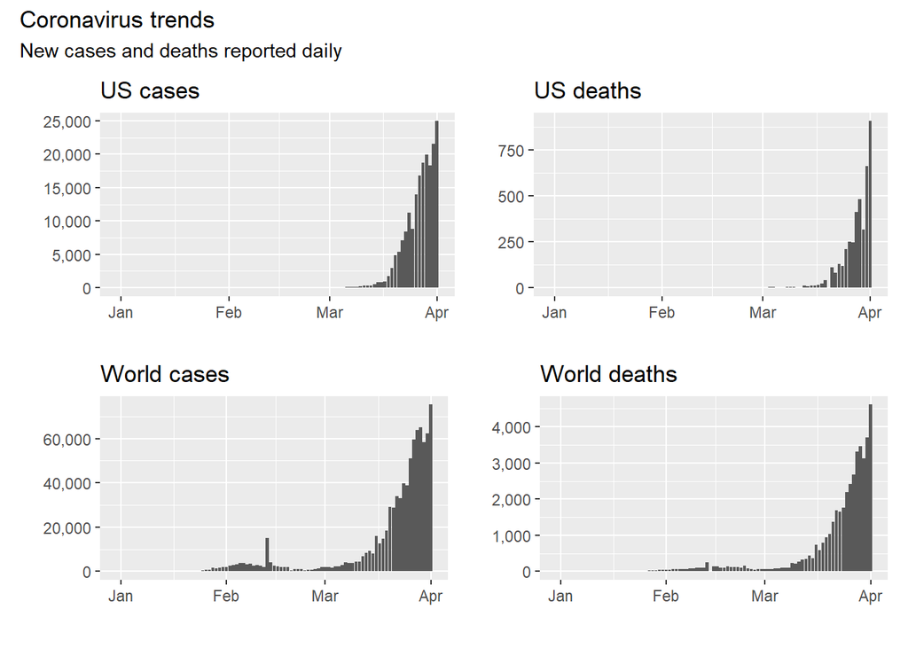

By comparison, here’s what is apparently happening in China, which is what we want the trend to be in the United States and worldwide.

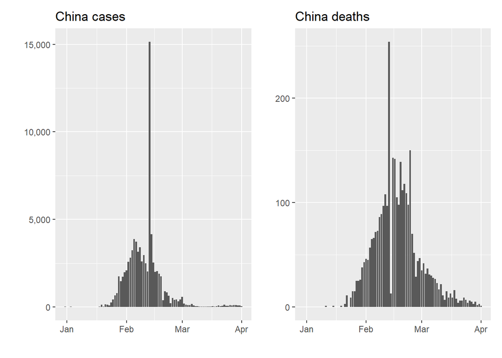

Finally, here is what is apparently happening in Italy. It looks like new cases and new deaths are starting to decline, but it’s still pretty ugly.

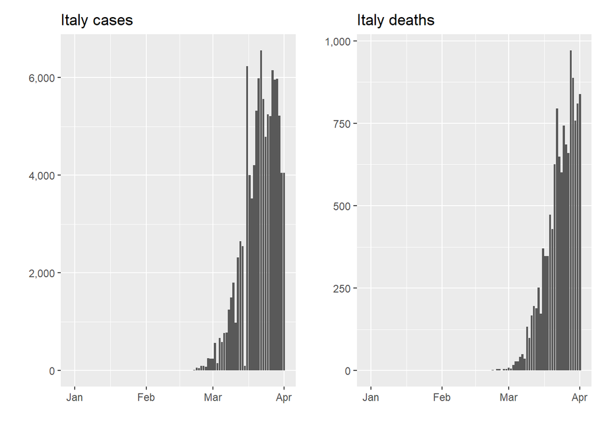